# Chap_2_ggplot

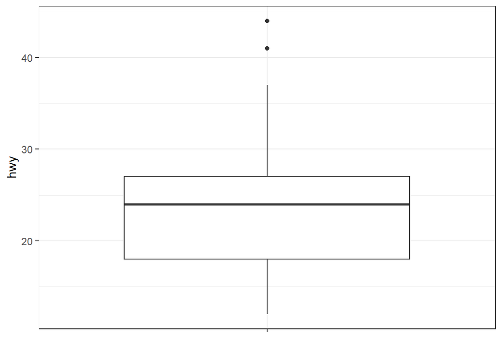

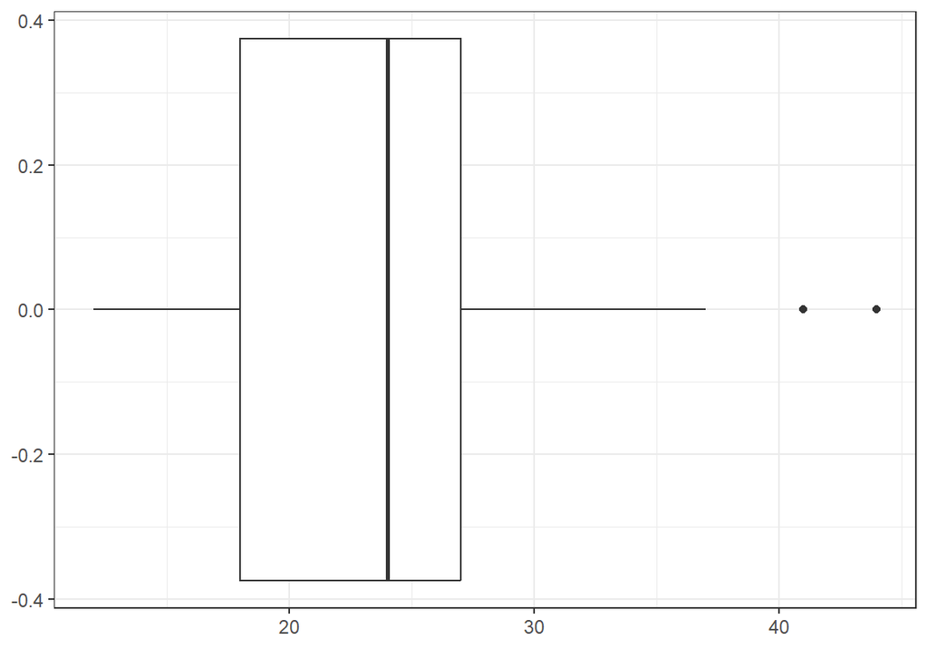

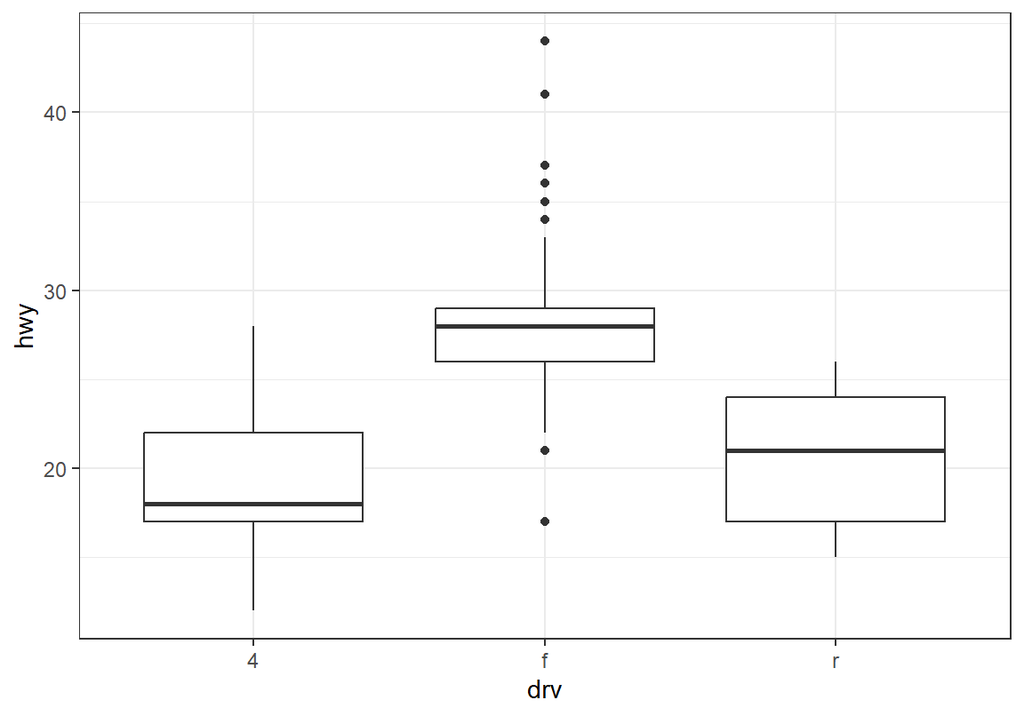

```r
# gauche
ggplot(mpg, aes(x = "", y = hwy))  +
  geom_boxplot() +
    labs(x = NULL)
ggplot(mpg, aes(x = hwy))  +
  geom_boxplot() +
    labs(x = NULL)

# droite
ggplot(mpg, aes(x = drv, y = hwy)) +
  geom_boxplot()
```

On peut spécifier d’autres arguments comme par exemple `varwidth = TRUE` qui permet de varier la largeur des boîtes en fonctions des effectifs de chaque classe et `outlier.shape = NA` qui supprime l’affichage des outliers:

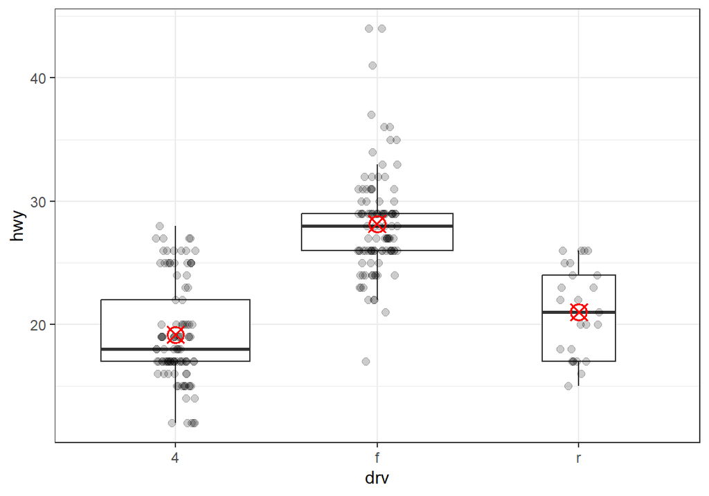

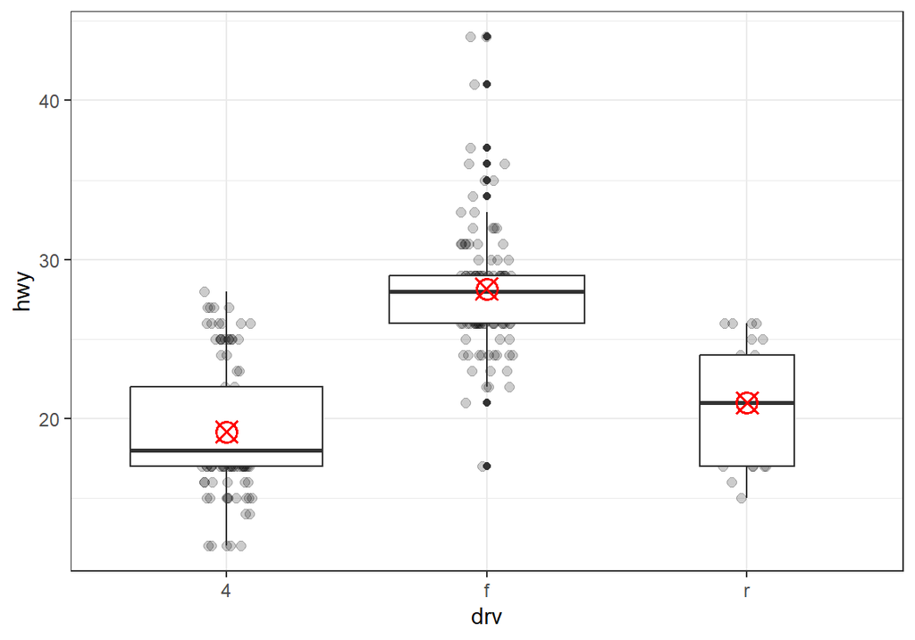

```r
ggplot(mpg, aes(x = drv, y = hwy)) +
  geom_boxplot(varwidth = TRUE, outlier.shape = NA) + # Ne pas utiliser outlier.shape=NA car suppr les outliers
  geom_jitter(alpha = 0.2, size = 2, width = 0.1, height = 0) +
  stat_summary(fun = mean, shape = 13, size = 1, colour = "red") # notez l'utilisation de stat_summary()

# Attention à ne pas mettre le boxplot sur les points !
ggplot(mpg, aes(x = drv, y = hwy)) +
  geom_jitter(alpha = 0.2, size = 2, width = 0.1, height = 0) +
  geom_boxplot(varwidth = TRUE) +
  stat_summary(fun = mean, shape = 13, size = 1, colour = "red") # notez l'utilisation de stat_summary()
```

- `geom_smooth()`

  Permet de tracer une courbe de tendance. Par défaut, rajoute un intervalle de confiance de 95%, pour le retirer, utiliser `se = FALSE`. L’argument `method` contrôle la méthode utilisée pour tracer la courbe. Par défaut, cet argument est fixé à “loess”, ce qui signifie que la fonction `loess()` est appelée pour produire une courbe lissée non-paramétriquement. Parmi les autres méthodes qu’il est possible d’utiliser, on retrouve `lm`, pour un modèle linéaire, et `glm`, pour un modèle linéaire généralisé.

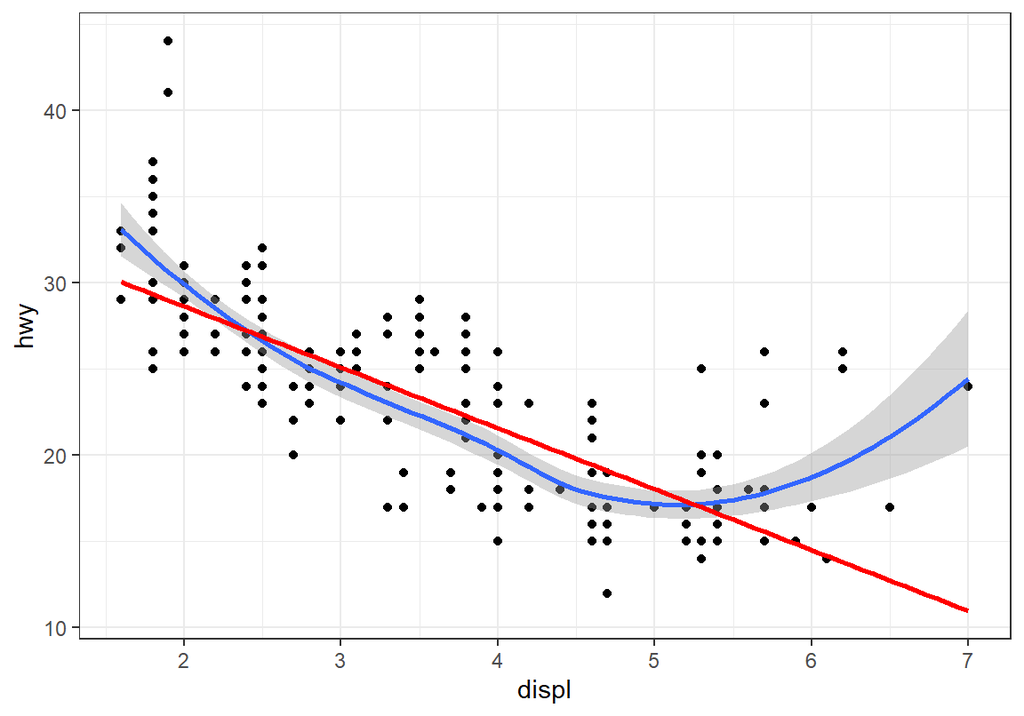

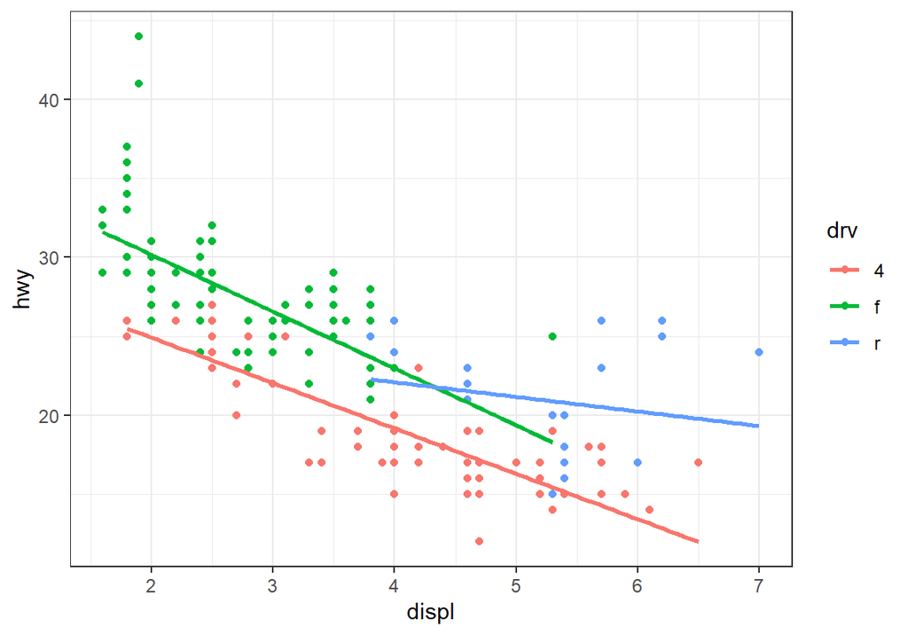

```r
p <- ggplot(mpg, aes(x = displ, y = hwy)) + geom_point()

p + geom_smooth() + # gauche
  geom_smooth(method = "lm", se = FALSE, col="red")
p + aes(color = drv) + geom_smooth(method = "lm", se = FALSE) # droite
# Ici par valeur de drv car précisé dans la fonction aes() !
```

- `geom_histogram()`

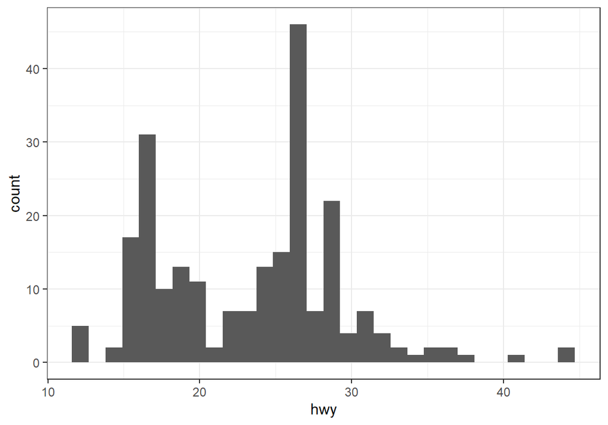

```r
ggplot(mpg, aes(x = hwy)) +
  geom_histogram()
```

L’un des problèmes avec les histogrammes est le choix du nombre de classes (par défaut ggplot en prend 30). Une formule utile est `nclass.Sturges()` qui permet de calculer un nombre de classes optimal.

```r
nclass.Sturges(mpg$hwy)
```

```
## [1] 9
```

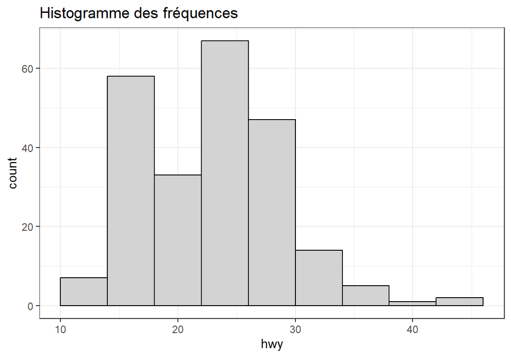

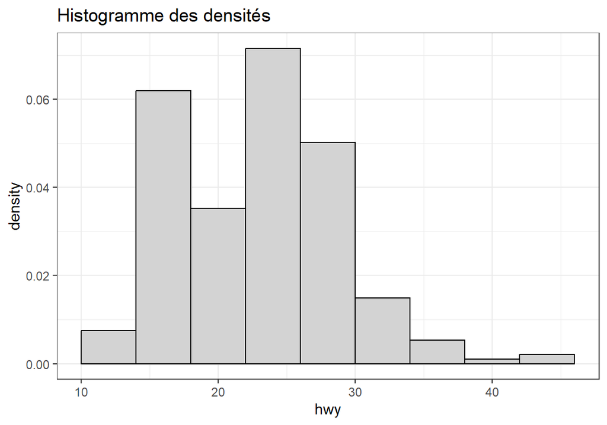

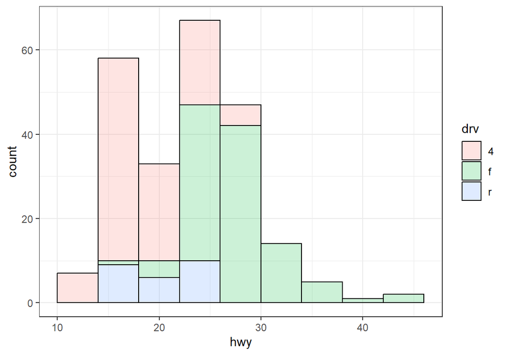

```r
# gauche
ggplot(mpg, aes(x = hwy)) +
  geom_histogram(bins  = 9, color = "black", fill = "lightgray") +
  labs(title = "Histogramme des fréquences")
# droite
ggplot(mpg, aes(x = hwy)) +
  geom_histogram(aes(y = ..density..), bins  = 9, color = "black", fill = "lightgray") +
  labs(title = "Histogramme des densités")

ggplot(mpg, aes(x=hwy)) +
    geom_histogram(bins=9, color="black", aes(fill=drv), alpha=.2)
```

Ci-dessus, `..density..` fait référence à la variable density créée et stockée automatiquement, en interne, par ggplot. En générale, pour accéder à une variable interne à ggplot, il faut entourer son nom par deux points de chaque côté.

- `geom_density()`

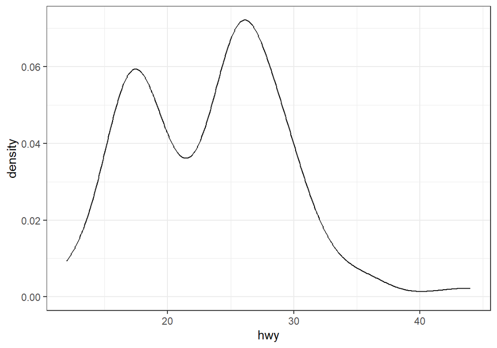

```r
ggplot(mpg, aes(x = hwy)) + geom_density()
```

Un argument important de `geom_density()` est `bw` (bandwidth) qui permet de contrôler le lissage des courbes. Par défaut, ggplot utilise la méthode de Scott. Ici un exemple de l’impact du bw sur la droite:

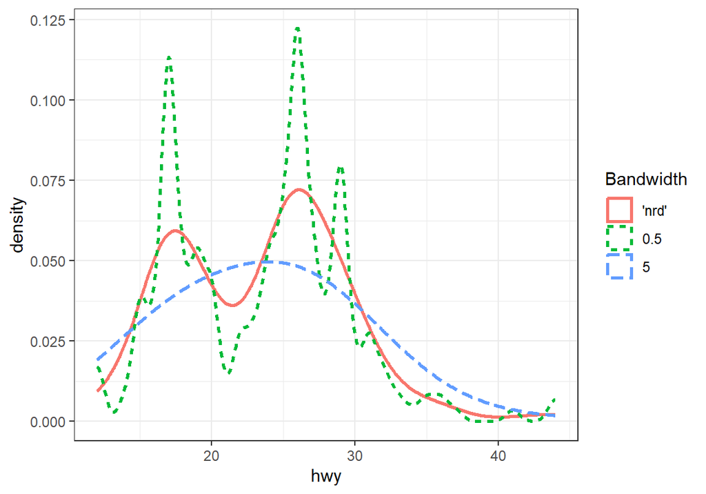

```r
ggplot(mpg, aes(x = hwy)) +
  geom_density(aes(color = "'nrd'", linetype = "'nrd'"), size = 1) +
  geom_density(bw = 0.5, aes(color = "0.5", linetype = "0.5"), size = 1) +
  geom_density(bw = 5, aes(color = "5", linetype = "5"), size = 1) +
  labs(color = "Bandwidth", linetype = "Bandwidth")
```

Pour mieux comprendre comment il marche, juxtaposont un histogram correspondant au nombre de bins:

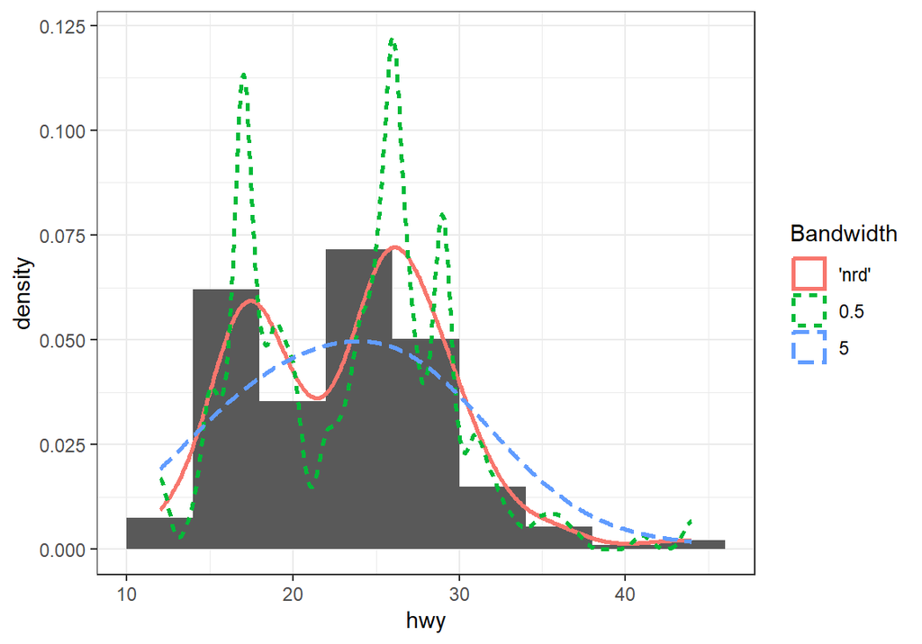

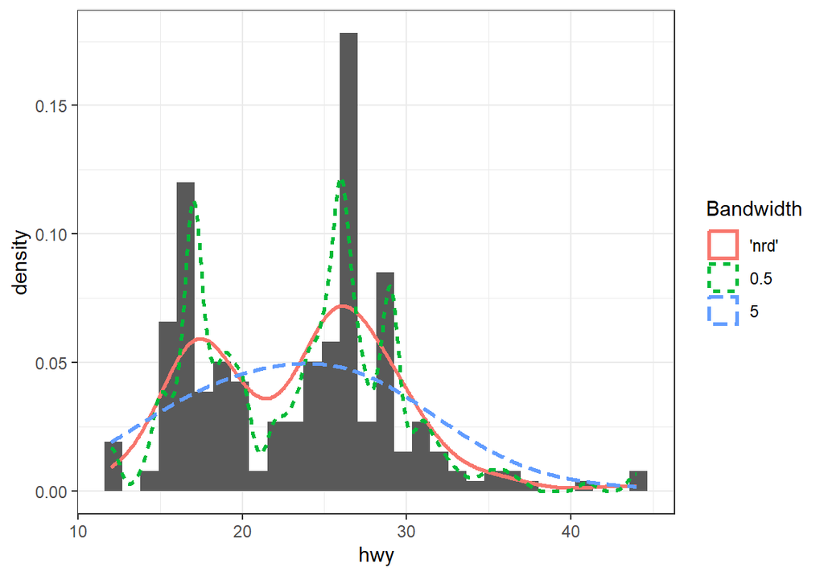

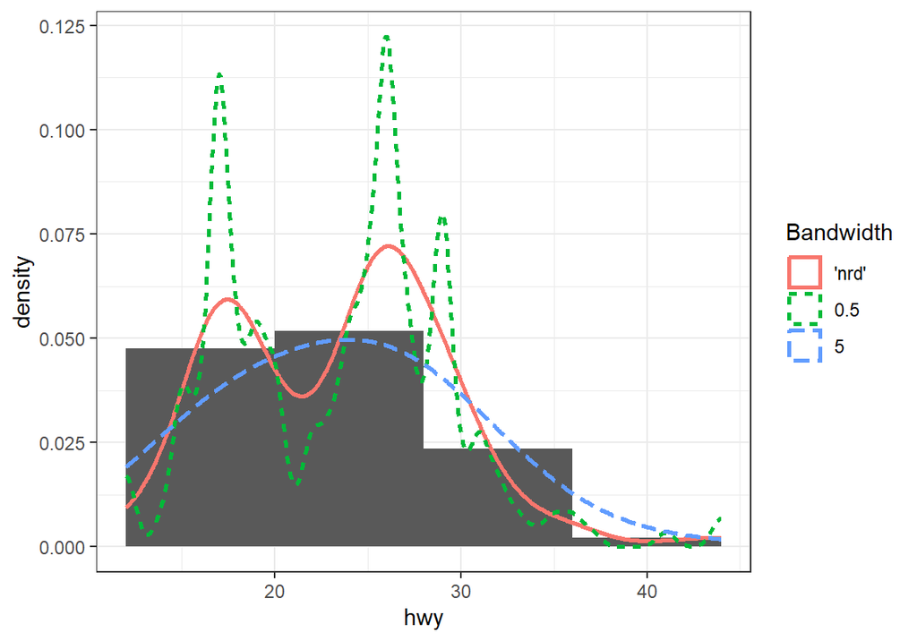

```r
ggplot(mpg, aes(x = hwy)) +
  geom_histogram(aes(y = ..density..), bins = 9) +
  geom_density(aes(color = "'nrd'", linetype = "'nrd'"), size = 1) +
  geom_density(bw = 0.5, aes(color = "0.5", linetype = "0.5"), size = 1) +
  geom_density(bw = 5, aes(color = "5", linetype = "5"), size = 1) +
  labs(color = "Bandwidth", linetype = "Bandwidth")

ggplot(mpg, aes(x = hwy)) +
  geom_histogram(aes(y = ..density..)) +
  geom_density(aes(color = "'nrd'", linetype = "'nrd'"), size = 1) +
  geom_density(bw = 0.5, aes(color = "0.5", linetype = "0.5"), size = 1) +
  geom_density(bw = 5, aes(color = "5", linetype = "5"), size = 1) +
  labs(color = "Bandwidth", linetype = "Bandwidth")
ggplot(mpg, aes(x = hwy)) +
  geom_histogram(aes(y = ..density..), bins = 5) +
  geom_density(aes(color = "'nrd'", linetype = "'nrd'"), size = 1) +
  geom_density(bw = 0.5, aes(color = "0.5", linetype = "0.5"), size = 1) +
  geom_density(bw = 5, aes(color = "5", linetype = "5"), size = 1) +
  labs(color = "Bandwidth", linetype = "Bandwidth")
```

Ici des exemples où l’on superpose plusieurs densités:

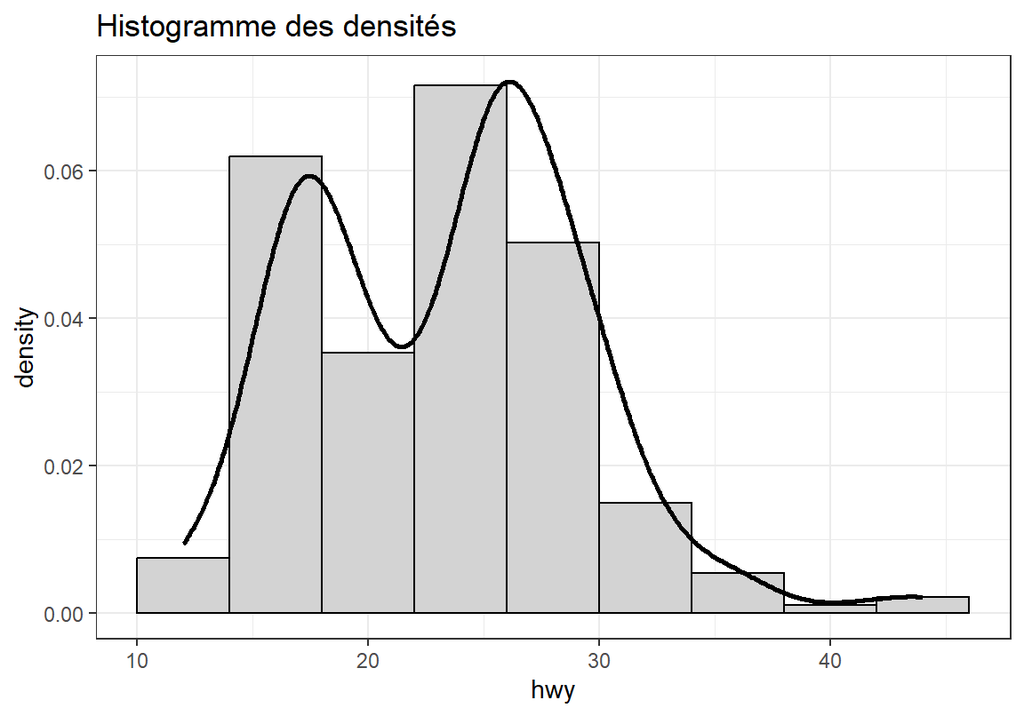

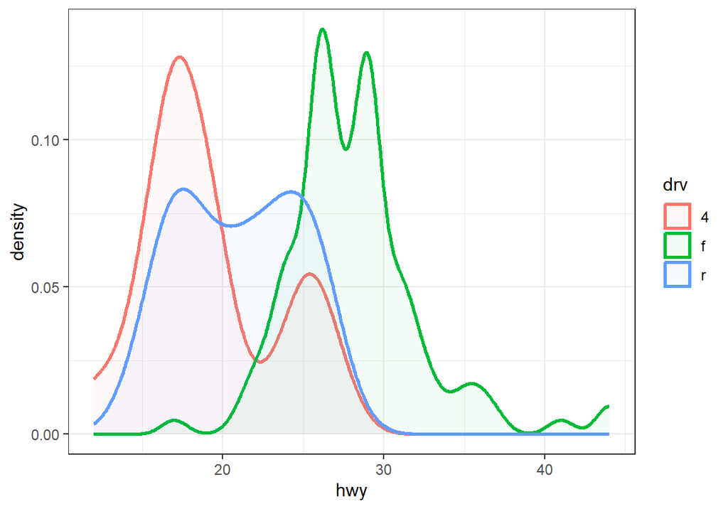

```r
# gauche
ggplot(mpg, aes(x = hwy)) +
  geom_histogram(aes(y = after_stat(density)), bins  = 9, color = "black", fill = "lightgray") +
  geom_density(size = 1) +
  labs(title = "Histogramme des densités")
# droite
ggplot(mpg, aes(x = hwy, color = drv, fill = drv)) +
  geom_density(size = 1, alpha = 0.05)
```

- `geom_violin()`

  Un graphique en violon (violin plot, en anglais) est constitué de deux graphiques de densité identique retournés et affichés en miroir l’un en face de l’autre.

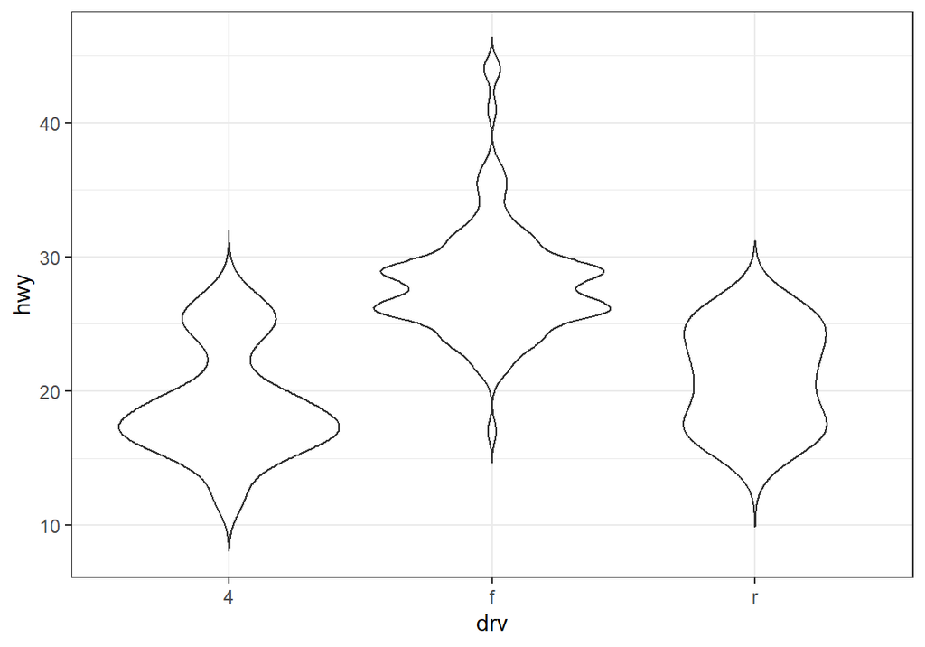

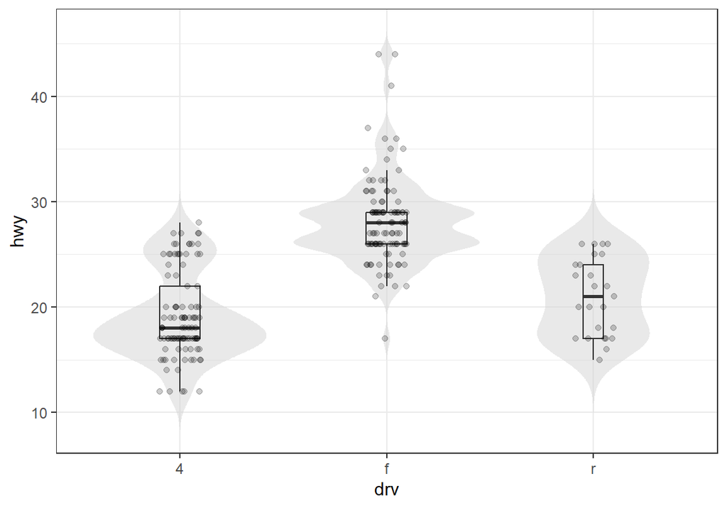

```r
# gauche
ggplot(mpg, aes(x = drv, y = hwy)) + geom_violin(trim = FALSE)
# droite
ggplot(mpg, aes(x = drv, y = hwy)) +
  geom_violin(color = NA, fill = "lightgray", alpha = 0.5, trim = FALSE) +
  geom_boxplot(width = 0.2, varwidth = TRUE, outlier.shape = NA, fill = NA) +
  geom_jitter(width = 0.1, height = 0, alpha = 0.2)
```

En réalité pas très utile…

- `geom_bar()`

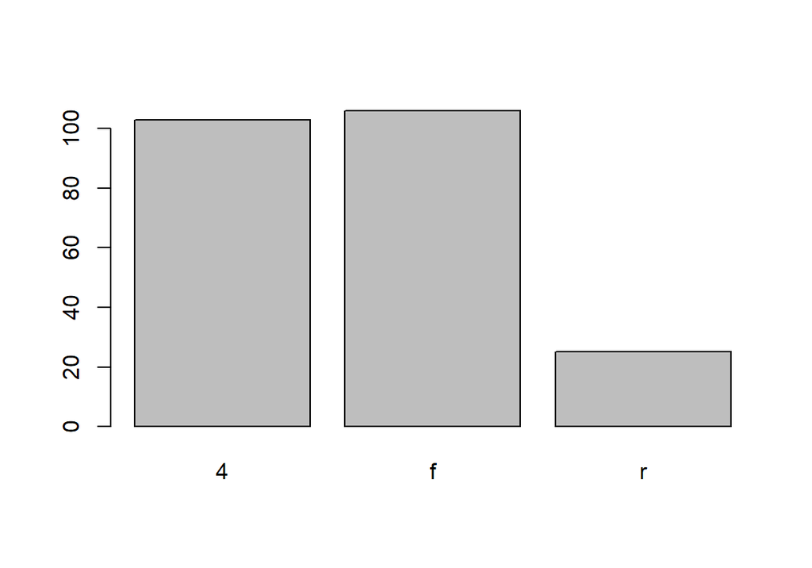

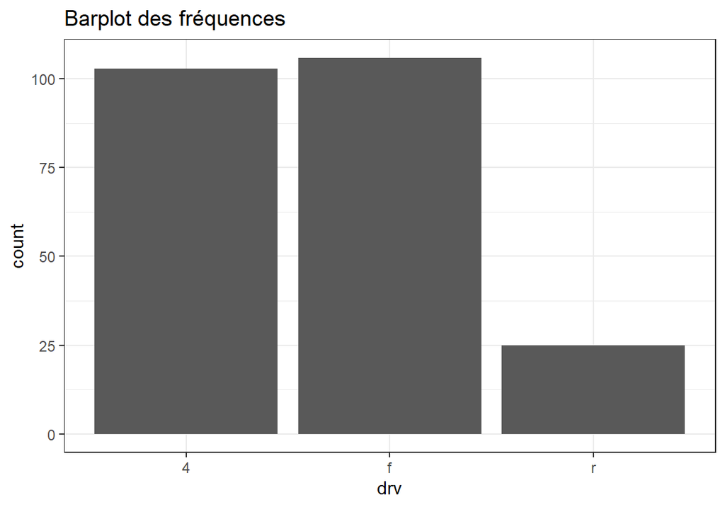

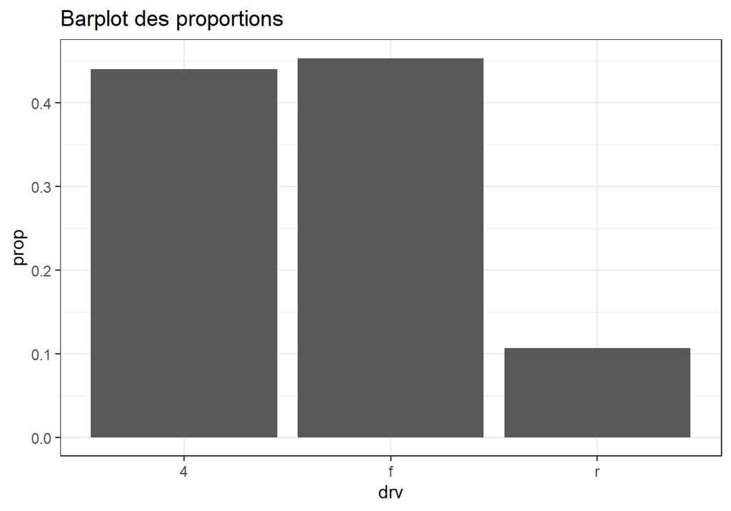

```r
# Plot de base
barplot(table(mpg$drv))
# Via ggplot
# gauche
ggplot(mpg, aes(x = drv)) + geom_bar() + labs(title = "Barplot des fréquences")
# droite
ggplot(mpg, aes(x = drv)) + geom_bar(aes(y = ..count.. / sum(..count..))) + labs(title = "Barplot des proportions", y = "prop")
# À la place de ..count.. il faut écrire after_stat(count)
# Pour les freq on doit les calculer manuellement
```

Une autre alternative à `geom_bar()`: `geom_col()` plus facile à utiliser quand on a déja les statistiques

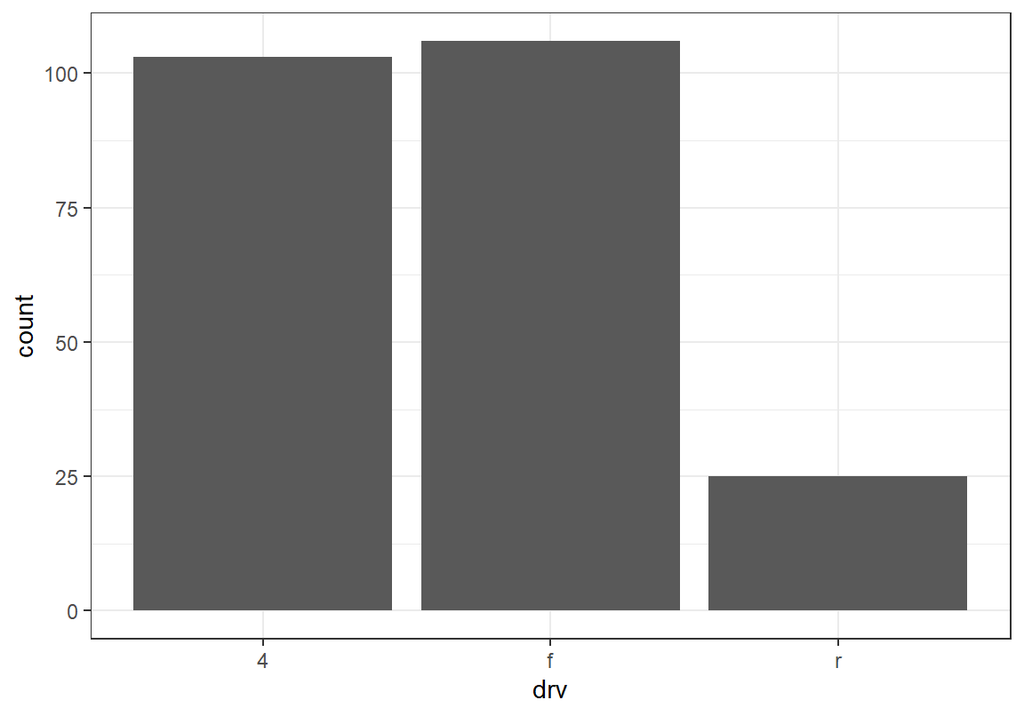

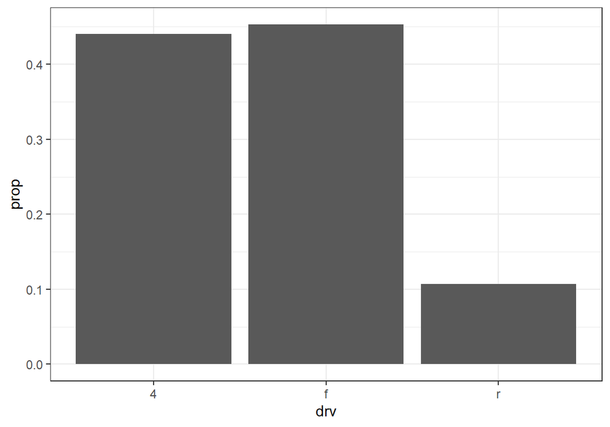

```r
xtabs(~drv, data = mpg) |> # pas bcp de diff avec table(mpg$drv) sauf que xtabs donne le nom de la variable d'intérêt alors que table donne "Var1"
  data.frame() |>
  ggplot() + geom_col(aes(x = drv, y = Freq)) + labs(y = "count")

xtabs(~drv, data = mpg) |>
  proportions() |>
     data.frame() |>
        ggplot() + geom_col(aes(x = drv, y = Freq)) + labs(y = "prop")
# Plus facile d'ajouter les freq plutôt que les réalisations
```

En rajoutant l’argument esthétique `fill`, on peut rajouter un facteur en plus dans le graphe. Par défaut, ggplot présente des barres empilées (ce qui est assez moche), pour les disposer côte à côté, utiliser `position = "dodge"`(par défaut `position = "stack"`). Une autre alternative est `position = "fill"` pour empiler les barres mais occuper entièrement l’axe des y, favorisant les comparaisons.

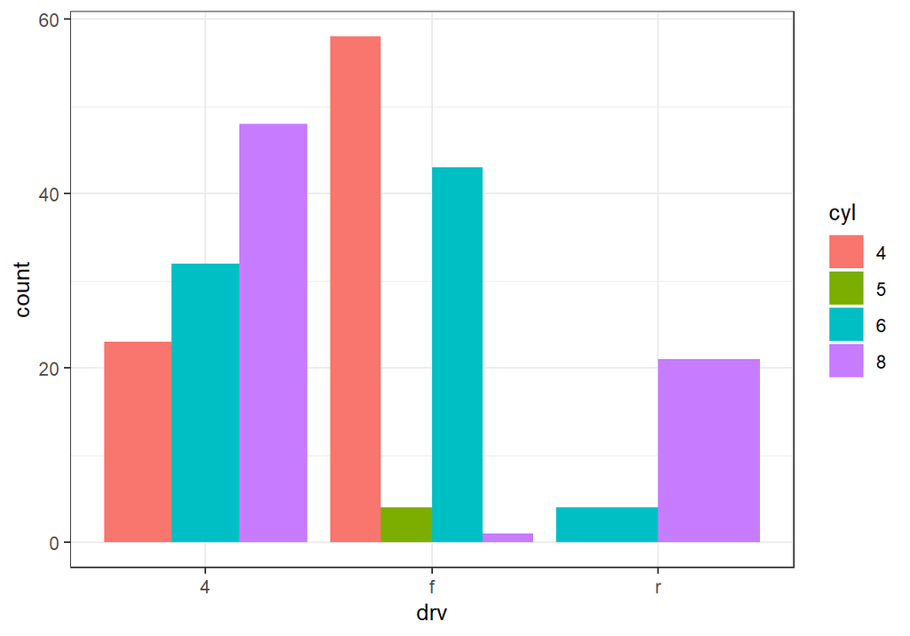

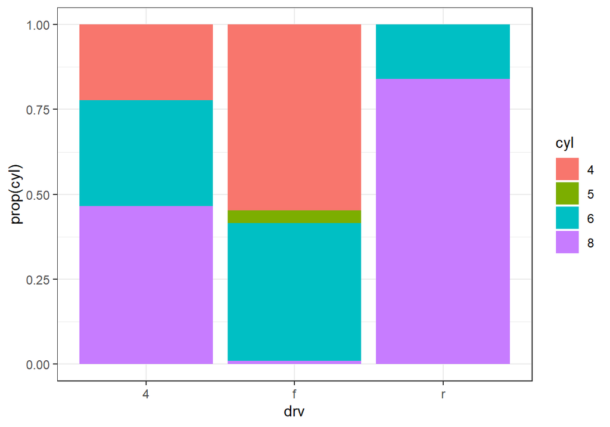

```r
# gauche
ggplot(mpg, aes(x = drv, fill = cyl)) + geom_bar(position = "dodge")
# droite
ggplot(mpg, aes(x = drv, fill = cyl)) +
  geom_bar(position = "fill") + labs(y = "prop(cyl)")
```

- `stat_function()`

Peut être utiliser pour tracer des courbes de fonctions.

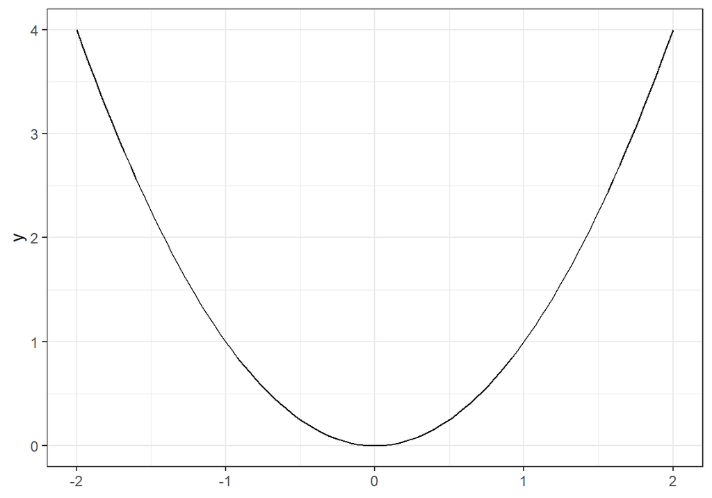

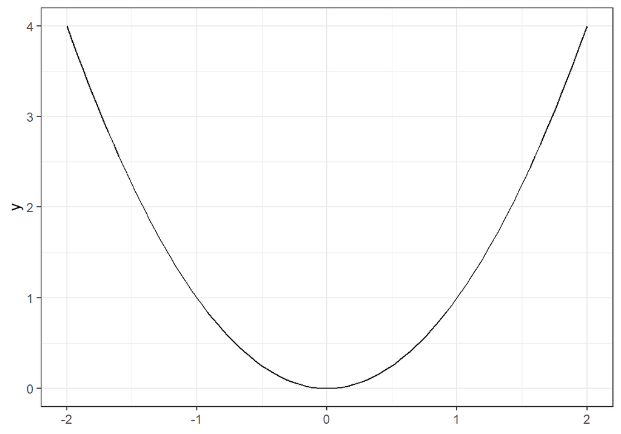

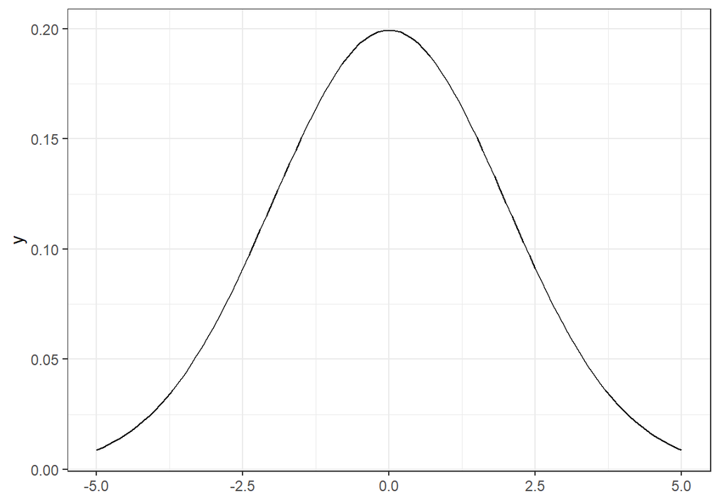

```r
# gauche
ggplot() + xlim(-2, 2) + stat_function(fun = \(x) x^2)
ggplot() + xlim(-2, 2) + stat_function(fun = function(x) x^2) # même chose
# droite
ggplot() + xlim(-5, 5) +
  stat_function(fun = dnorm, args = list(mean = 0, sd = 2))
# Intéressant pour ajouter des courbes de densité sur des données
```

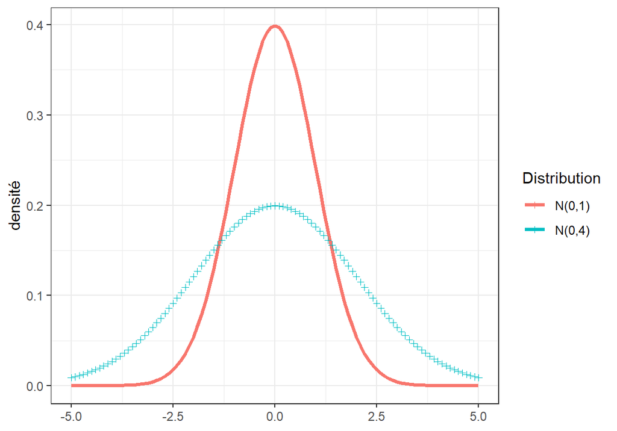

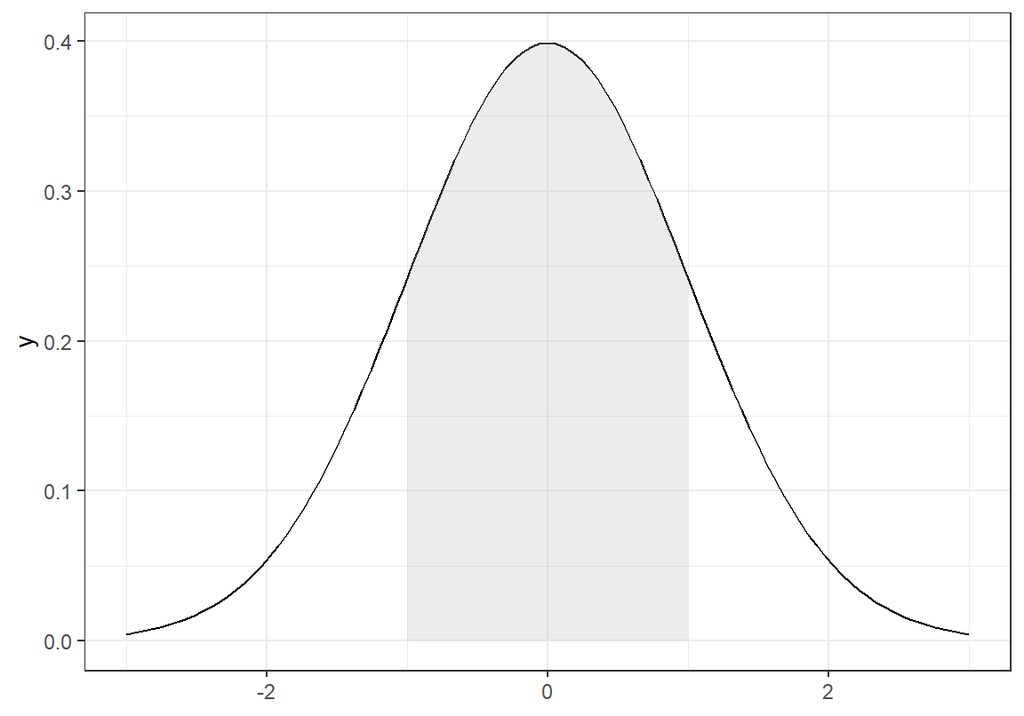

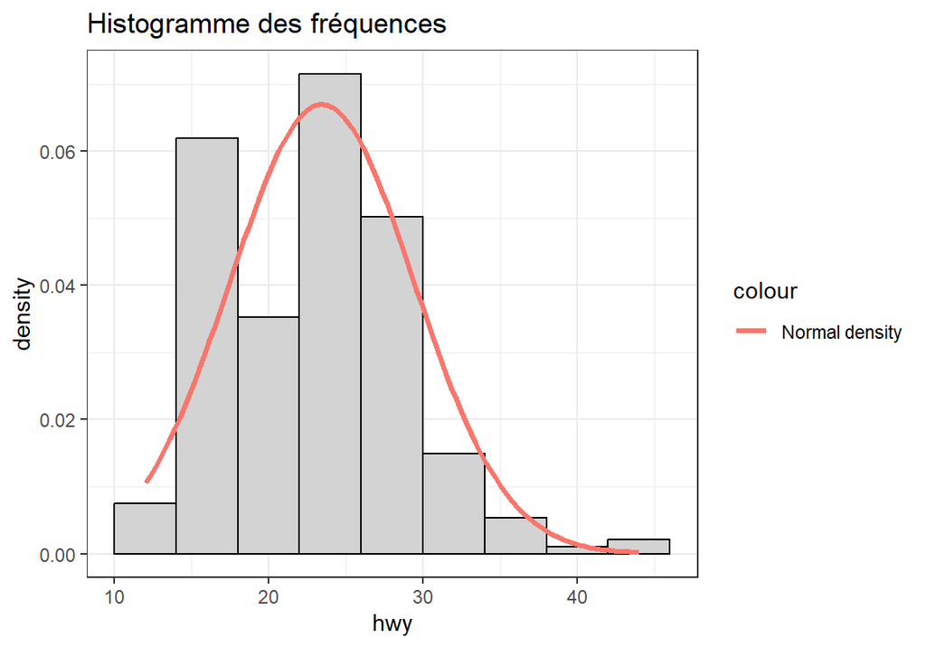

```r
# gauche
ggplot() + xlim(-5, 5) +
  stat_function(fun = dnorm, geom = "line", size = 1.2, mapping = aes(color = "N(0,1)")) +
  stat_function(fun = dnorm, args = list(mean = 0, sd = 2), geom = "point", size = 1.2, shape = 3, mapping = aes(color = "N(0,4)")) +
  labs(y = "densité", color = "Distribution")
# droite
ggplot() + xlim(-3, 3) +
  stat_function(fun = dnorm) +
  stat_function(fun = dnorm, xlim = c(-1, 1), geom = "area", fill = "gray", alpha = .3)

# Un exemple
ggplot(mpg, aes(x = hwy)) +
  geom_histogram(aes(y = ..density..),bins  = 9, color = "black", fill = "lightgray") +
  labs(title = "Histogramme des fréquences") +
    stat_function(fun= dnorm, geom="line", args=list(mean=mean(mpg$hwy), sd=sd(mpg$hwy)), mapping=aes(color= "Normal density"), size=1.2)
```

## Faceting

Le faceting permet de découper un graphique en plusieurs morceaux suivant les valeurs de variables catégorielles (un peu comme un tableau de contingence). Deux fonctions disponibles, facet_grid() et facet_wrap(), toutes deux similaires mais facet_grid() réalise une matrice alors que facet_wrap réalise une suite de graphique. Voici un exemple:

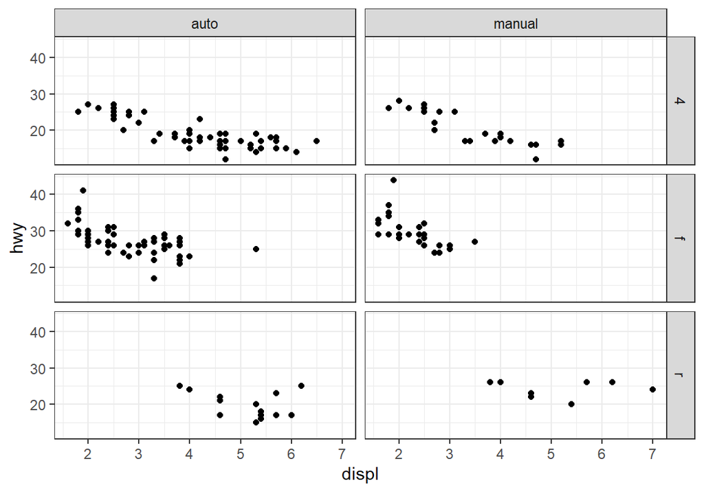

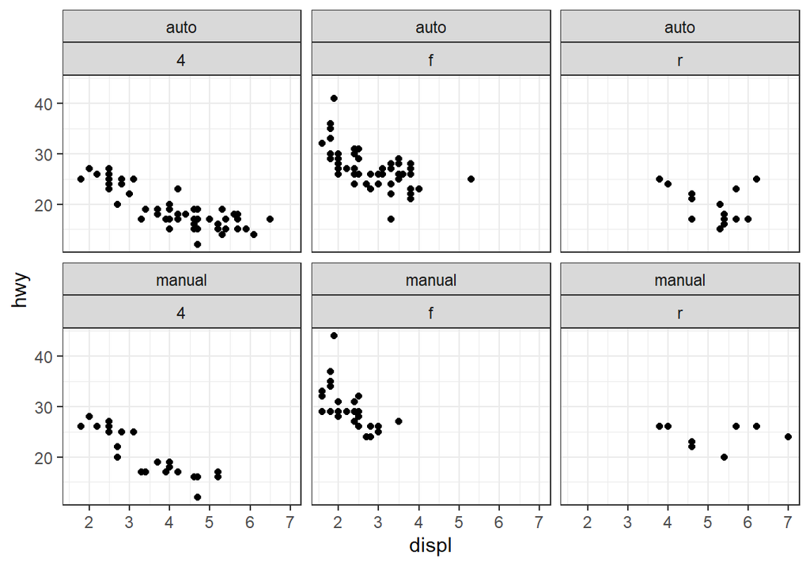

```r
# gauche
ggplot(mpg, aes(displ, hwy)) + geom_point() +
  facet_grid(cols = vars(trans), row = vars(drv))
# droite
ggplot(mpg, aes(displ, hwy)) + geom_point() +
  facet_wrap(facets = vars(trans, drv))
```

Par défaut, chaque facette est fournie avec un label qui montre la valeur du facteur de découpage. Par défaut aussi, les échelles des axes affichées sont les mêmes (fixes) pour toutes les groupes/facettes. Les arguments labeller et scales peuvent être évoqués pour modifier/contrôler ces deux éléments.

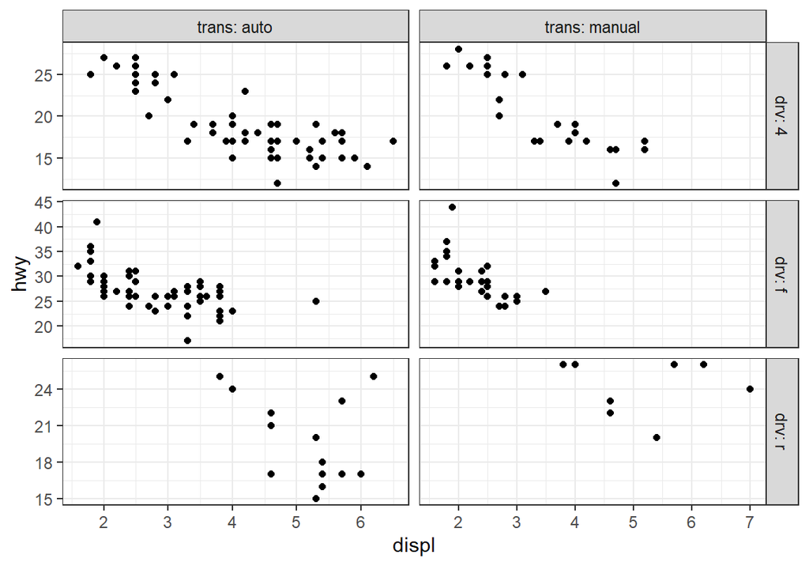

```r
ggplot(mpg, aes(displ, hwy)) + geom_point() +
  facet_grid(cols = vars(trans), row = vars(drv), labeller = "label_both", scales = "free")
```

## Functions in ggplot

Pour sauvegarder un bout de code ggplot et le réutilise plus tard, utiliser une liste:

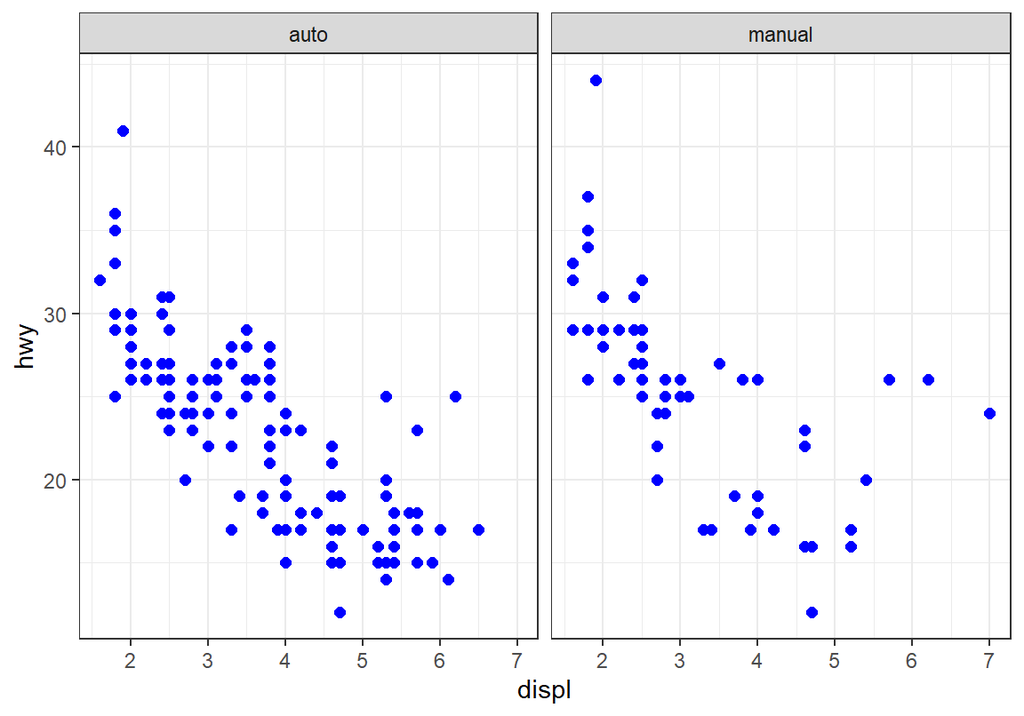

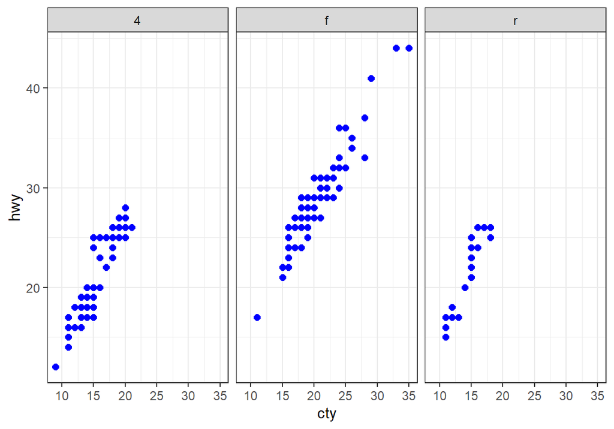

```r
ggplot(mpg, aes(x = displ, y = hwy)) + geom_point(color = "blue", size = 2) +
  theme_bw() + facet_wrap(vars(trans))
#Utilisation d'une variable pour réutiliser l'option ggplot
mygpt <- list(geom_point(color = "blue", size = 2), theme_bw())
ggplot(mpg, aes(x = cty, y = hwy)) + facet_wrap(vars(drv)) + mygpt
```

On pourrait se dire qu’écrire une fonction pour réaliser un graphique serait facile:

```r
mygptFun <- function(data, x, y, grp) {
  ggplot(data, aes(x, y)) + facet_wrap(vars(grp)) + mygpt
}
```

Mais malheureusement ça ne marche pas comme ça

```r
mygptFun(mpg, displ, hwy, trans)
```

Voici comment contourner cette erreur: via `{{` ou `.data`. Exemples:

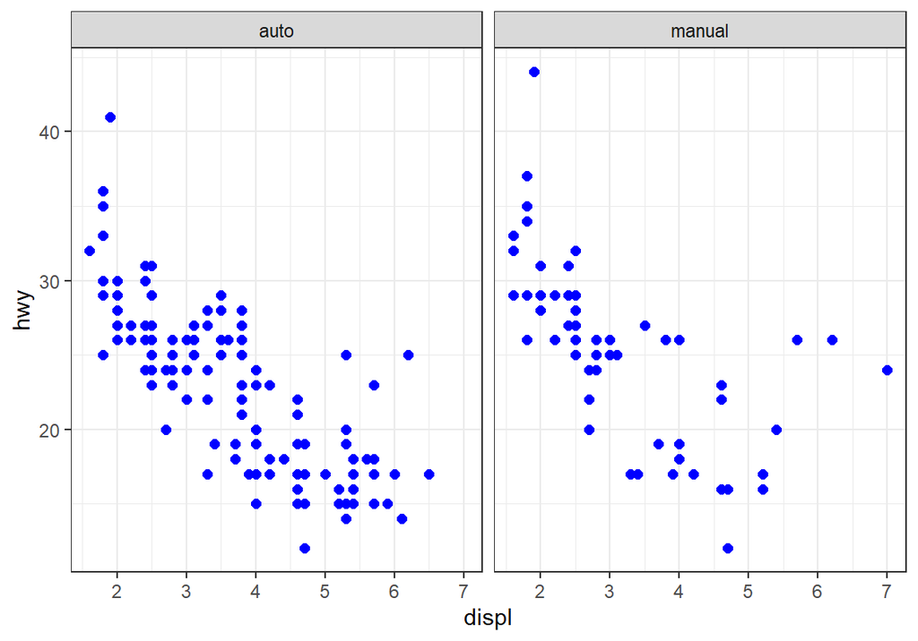

```r
#Function
mygptFun1 <- function(data, x, y, grp) {
  ggplot(data, aes({{ x }}, {{ y }})) + facet_wrap(vars({{ grp }})) + mygpt
}

mygptFun1(mpg, displ, hwy, trans) # {{}} pour ne pas avoir de problèmes avec la fonction et ggplot

# ou

mygptFun2 <- function(data, x, y, grp) {
  ggplot(data, aes(.data[[x]], .data[[y]])) + facet_wrap(vars(.data[[grp]])) +
    mygpt
}
#mygptFun2(iris, y=Sepal, x=Petal.Length, Species)
```

Une façon plus robuste est d’utiliser l’argument spécial `...` qui nous permet d’ajouter les arguments que l’on veut en plus (très utile !!):

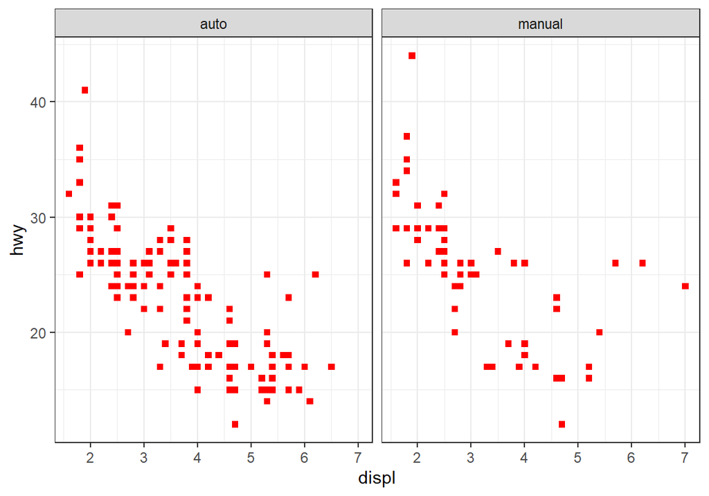

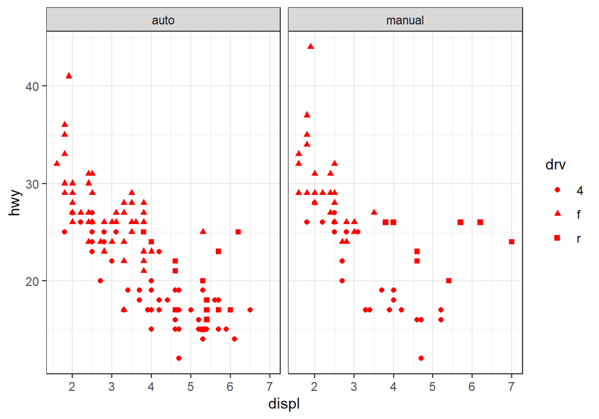

```r
mygptFun3 <- function(data, x, y, grp, ...) {
  ggplot(data, aes({{ x }}, {{ y }})) +
    facet_wrap(vars({{ grp }})) + geom_point(...) + theme_bw()
}
mygptFun3(mpg, displ, hwy, trans, color = "red", shape = 15)
# L'utilisation des ... permet de spécifier les options que l'on souhaite utiliser avec ggplot sans avoir à les spécifier dans la création de la fonction
mygptFun3(mpg, displ, hwy, trans, color = "red", aes(shape = drv))
```

## Extensions de ggplot

Petit plus pour créer des graphiques

```r
esquisse::esquisser(mpg)
```

# Advanced ggplot

## All geom_

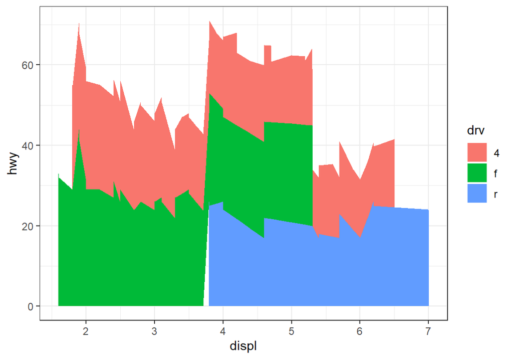

```r
p1 <- ggplot(mpg) + aes(x = displ, y = hwy)
p2 <- ggplot(mpg) + aes(x = displ)
p3 <- ggplot(mpg) + aes(x = hwy, y = drv)
p1 + aes(fill= drv) + geom_area() # Dégueulasse -> options : color, size, linetype, alpha, fill
```

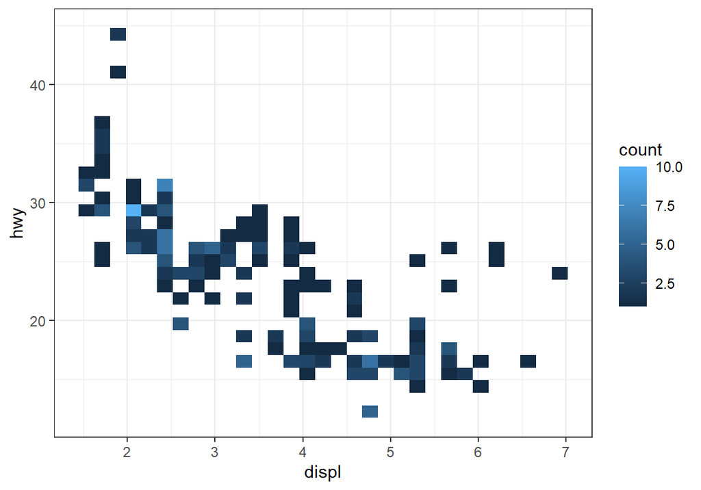

```r
p1 + geom_bin2d() # options : color, size, linetype, alpha, fill
```

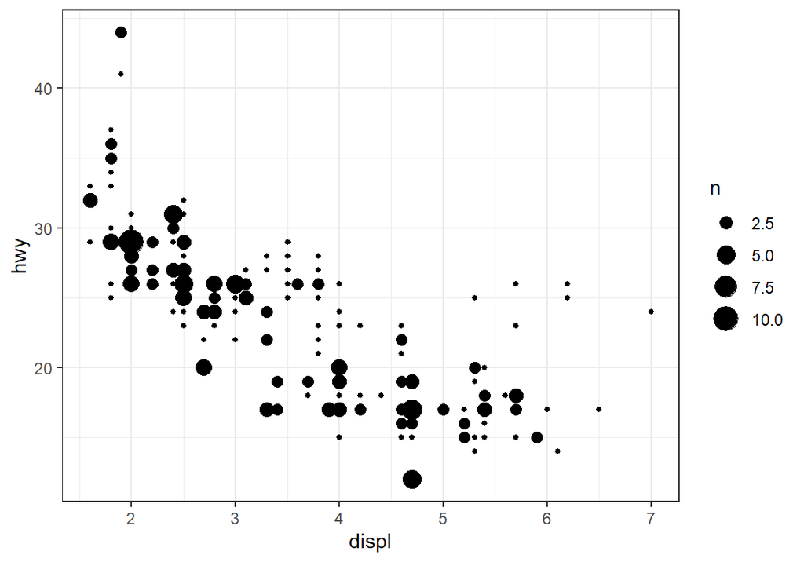

```r
p1 + geom_count() # options : color, size, linetype, alpha, fill, shape, stroke (change size of points)
```

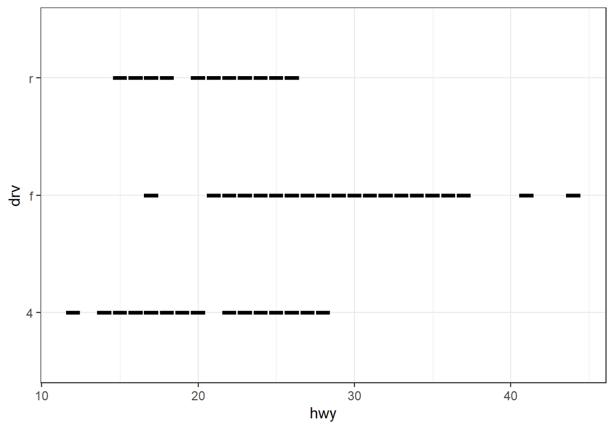

```r
p3 + geom_crossbar(ymin = 20, ymax = 40) # wtf, options : color, size, linetype, alpha
```

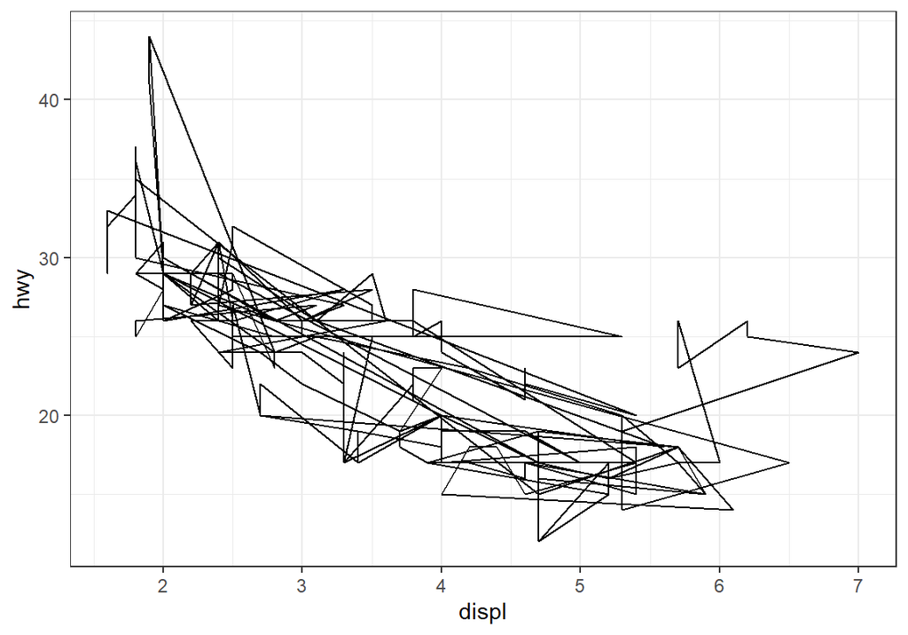

```r
p1 + geom_path() # line up the obs in the order they appear in the dataset
```

```r
# En vrai ils sont tous nuls mdr
```

## Patchwork package

```r
require(patchwork)
```

The last plot is the active one, so it receives the additional arguments :

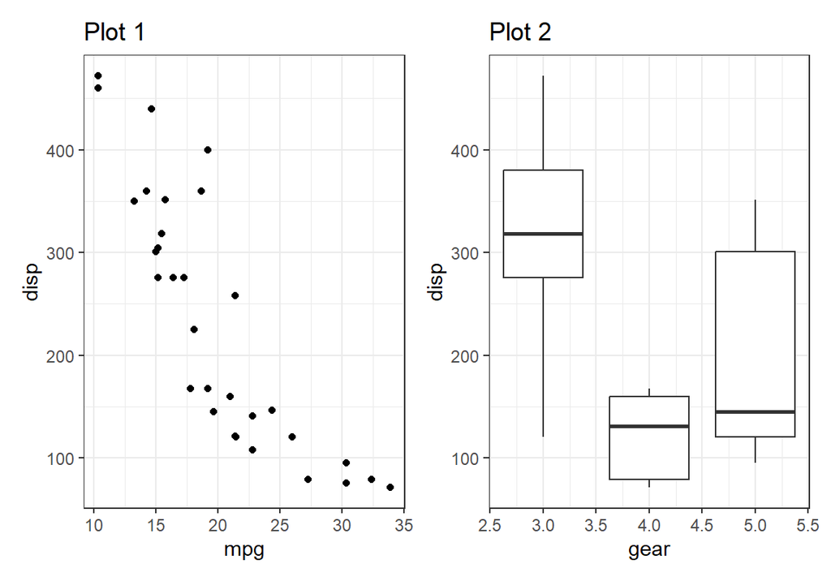

```r
p1 <- ggplot(mtcars) +
  geom_point(aes(mpg, disp)) +
  ggtitle('Plot 1')

p2 <- ggplot(mtcars) +
  geom_boxplot(aes(gear, disp, group = gear)) +
  ggtitle('Plot 2')

p3 <- ggplot(mtcars) +
  geom_point(aes(hp, wt, colour = mpg)) +
  ggtitle('Plot 3')

p4 <- ggplot(mtcars) +
  geom_bar(aes(gear)) +
  facet_wrap(facet= vars(cyl)) +
  ggtitle('Plot 4')

p1 + p2
```

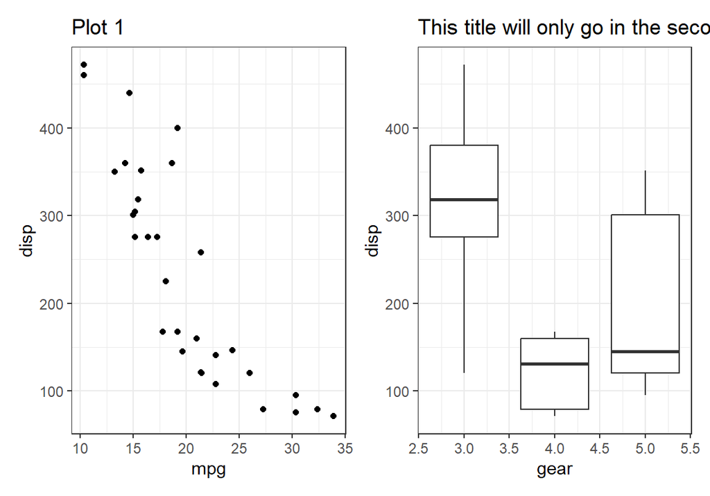

```r
p1 + p2 + labs(title = "This title will only go in the second plot")
```

To control the layout of the graphs, use plot_layout

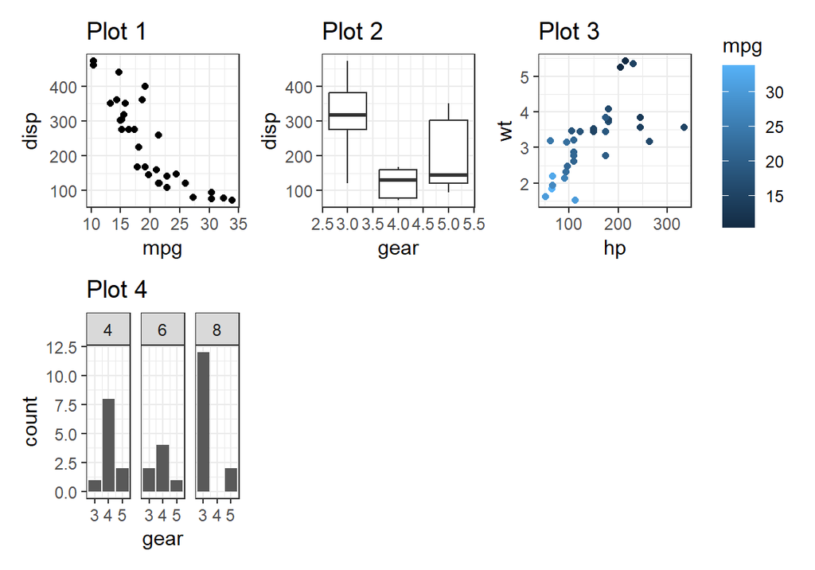

```r
p1 + p2 + p3 + p4 + plot_layout(ncol = 3, byrow = T)
```

To add a title, subtitles, use plot_annotation

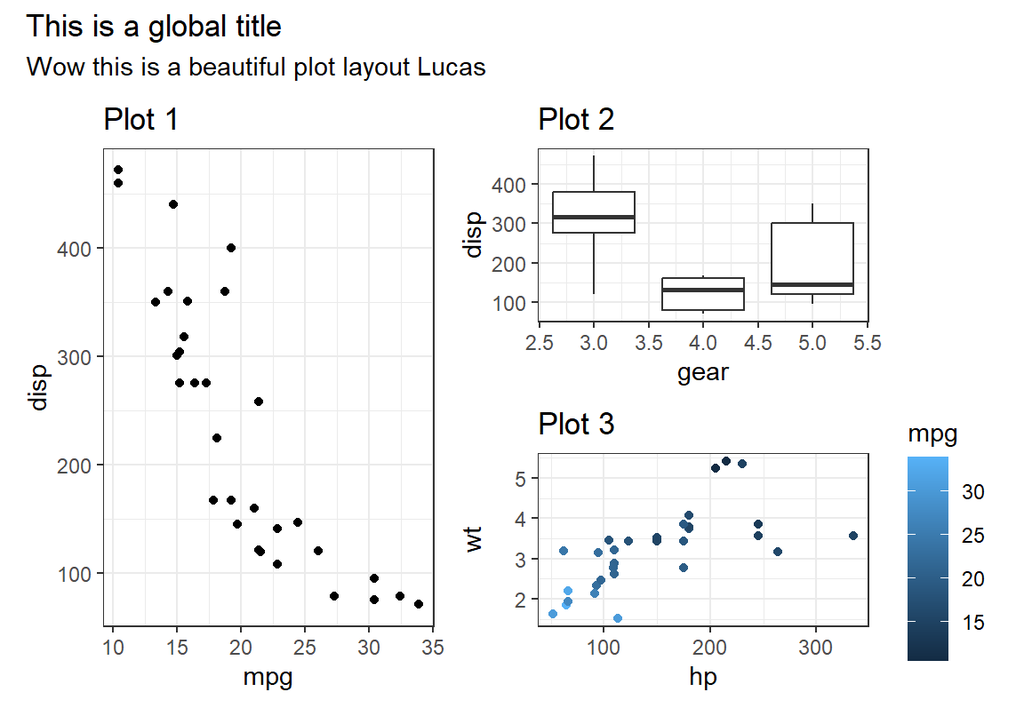

```r
(p1 | (p2/p3)) + plot_annotation(title = "This is a global title", subtitle = "Wow this is a beautiful plot layout Lucas")
```

To add space between plots, use `plot_spacer()`

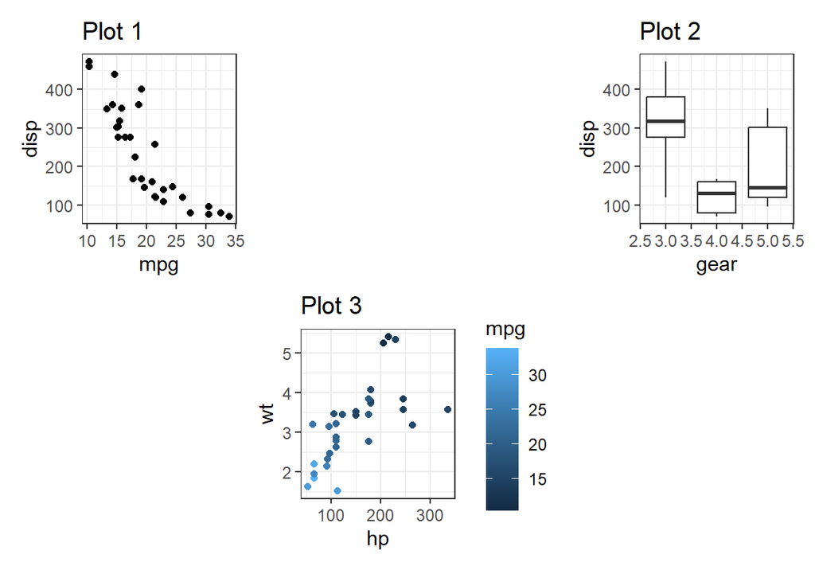

```r
p1 + plot_spacer() + p2 + plot_spacer() + p3+ plot_spacer()
```

To add insets, use `inset_element`

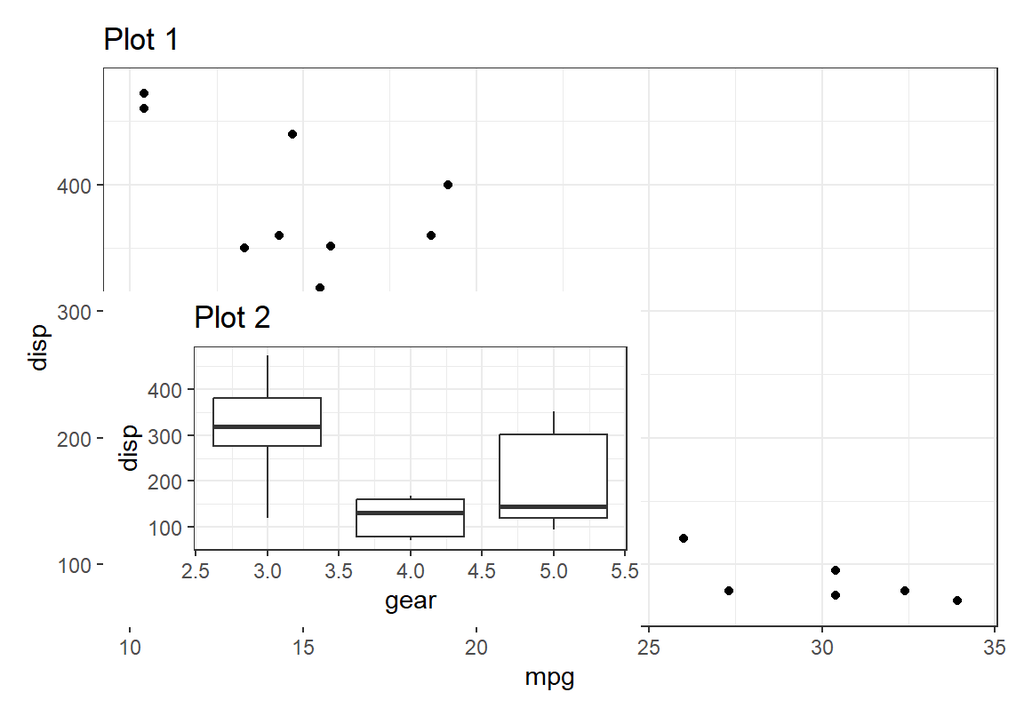

```r
p1 + inset_element(p2, bottom = 0, right = 0.6, top = 0.6, left = 0)
```

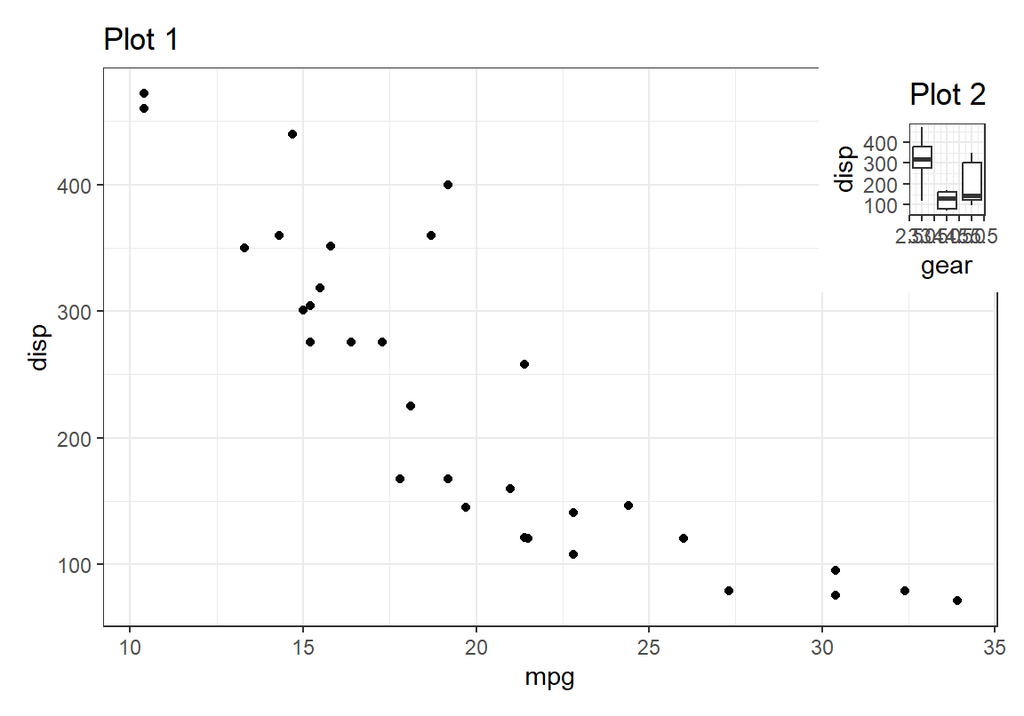

```r
p1 + inset_element(p2, bottom = 0.6, right = 1, top = 1, left = 0.8)
```

To control where the legend will be, use the guides `option` in `plot_layout`

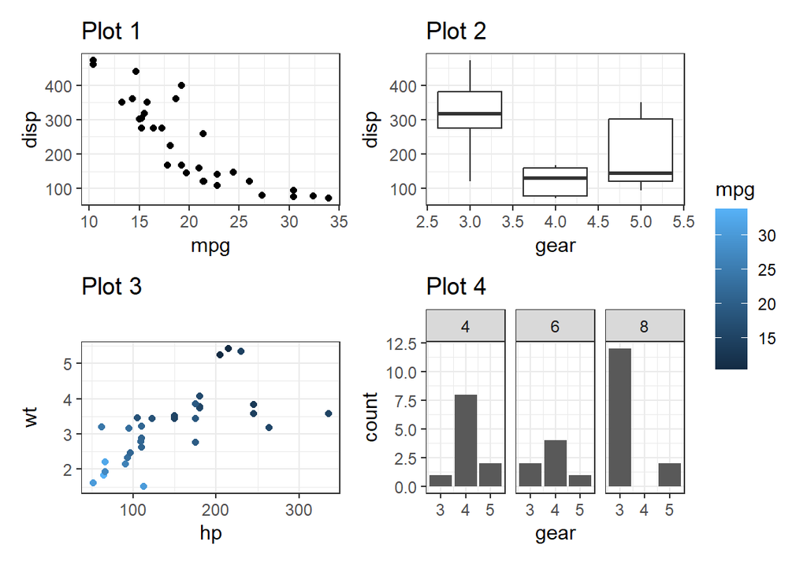

```r
# collect to put the legend beside all plots
p1 + p2 + p3 + p4 + plot_layout(guides = "collect")
```

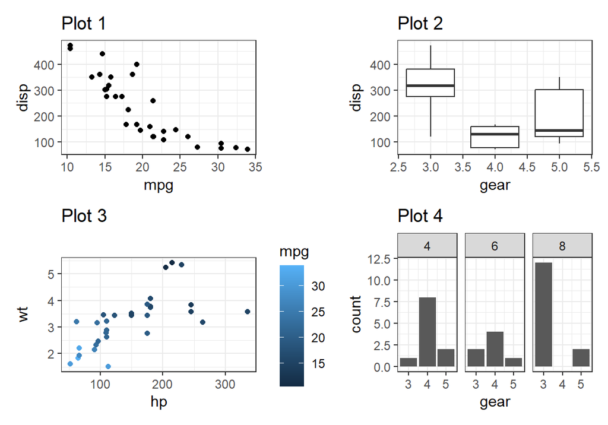

```r
# keep to put the legend beside their specific plot
p1 + p2 + p3 + p4 + plot_layout(guides = "keep")
```

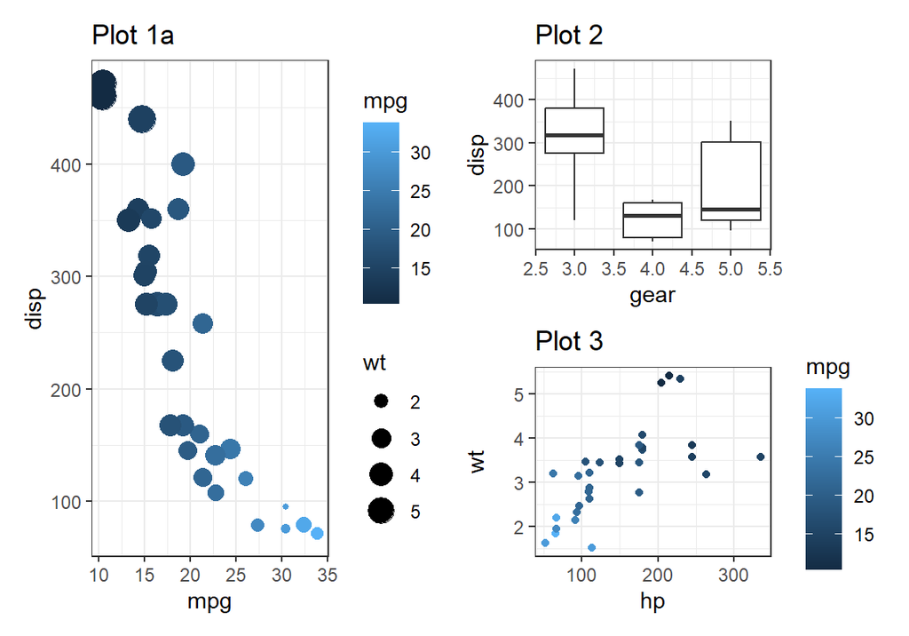

```r
p1a <- ggplot(mtcars) +
  geom_point(aes(mpg, disp, colour = mpg, size = wt)) +
  ggtitle('Plot 1a')

# If several plots have identical legend, collect suppress the duplicate
p1a | (p2 / p3)
```

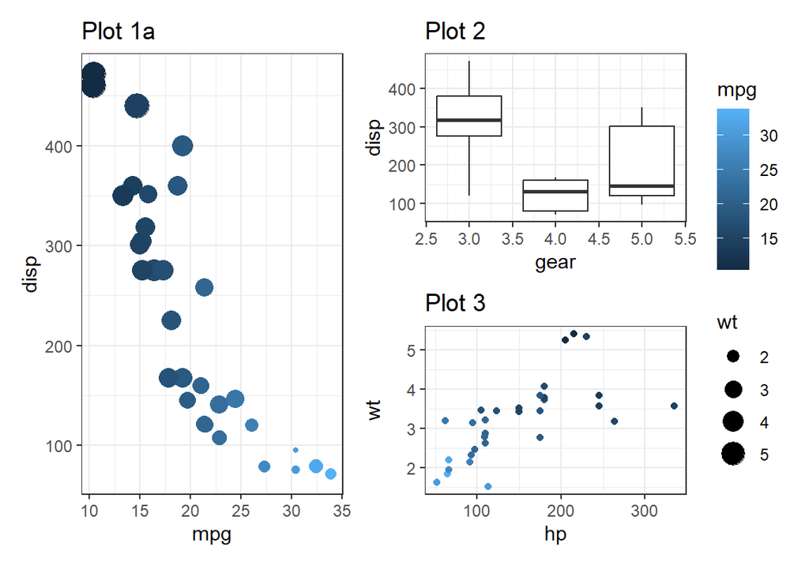

```r
(p1a | (p2 / p3)) + plot_layout(guides = "collect")
```

## Advanced options

When we are legending our data by a continuous variable, sometimes we want to choose the number displayed in the legend. For example, compare :

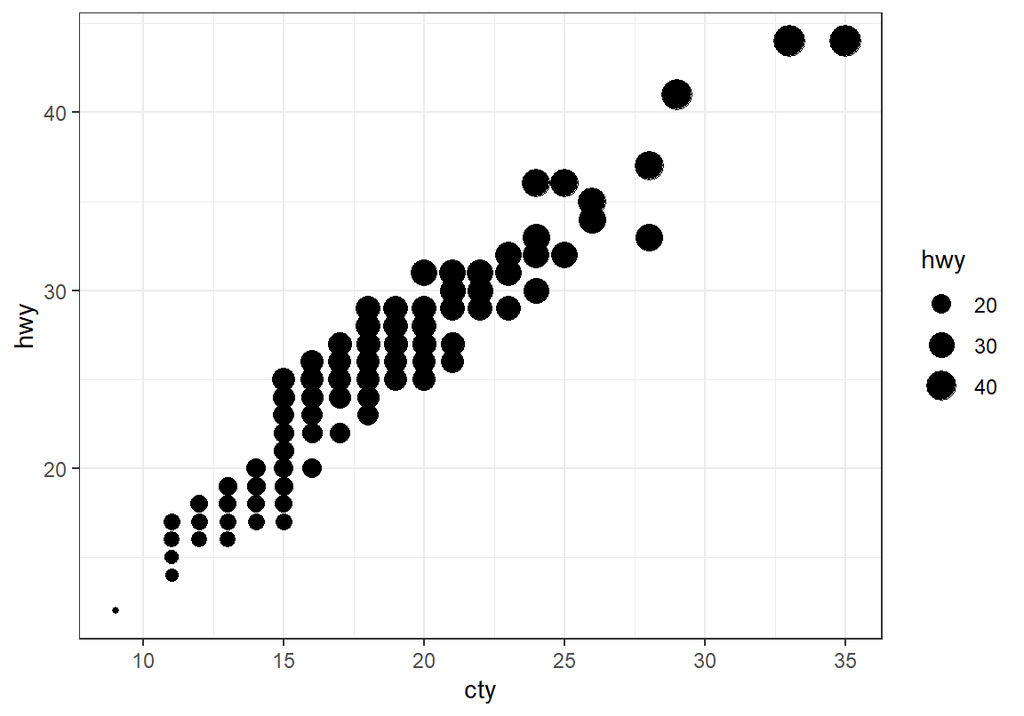

```r
ggplot(mpg) + aes(cty, hwy, size = hwy) + geom_point()
```

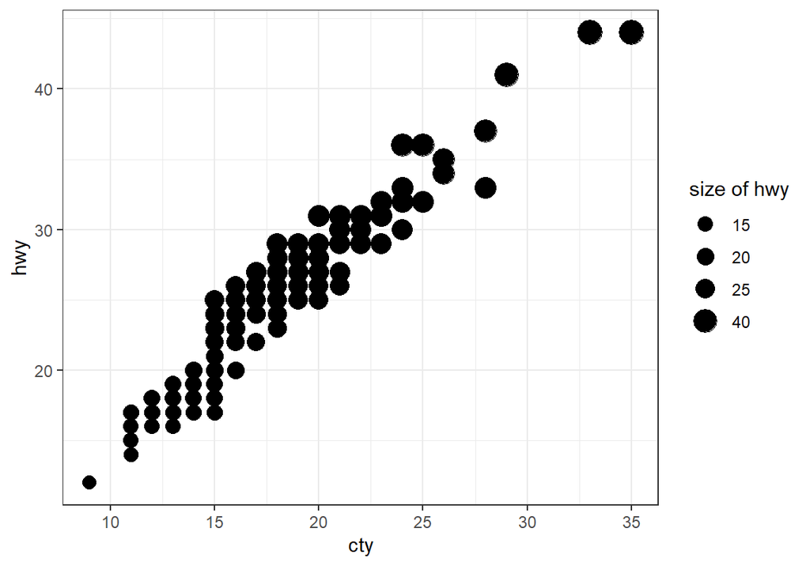

```r
ggplot(mpg) + aes(cty, hwy, size = hwy) + geom_point() + scale_size_area("size of hwy", breaks = c(15,20,25,40))
```

To remove a legend, use `theme(legend.position = "none)`

If we want to show how the mean of a continuous variable change between values of a categorical one, use the stat option in geom_bar

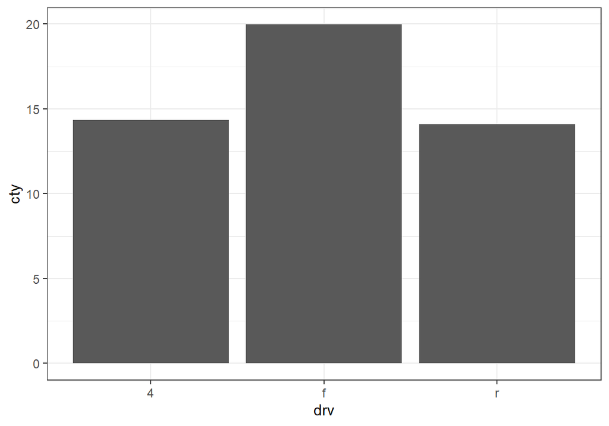

```r
ggplot(mpg) + aes(drv, cty) +
  geom_bar(stat = "summary_bin", fun = mean)
```